# Analysis of Airbnb Data in NYC 2019

Kenneth Tay

17 Oct 2019

## Introduction

This is a short data analysis of Airbnb listings in New York City (NYC) in 2019. The data was taken from https://www.kaggle.com/dgomonov/new-york-city-airbnb-open-data/.

Package imports:

```r
library(tidyverse)
library(knitr)
```

Read in dataset:

```r
df <- read_csv("airbnb_nyc_2019.csv",
               col_types = cols(host_id = col_character(),
                                id = col_character(),
                                last_review = col_date(format = "%Y-%m-%d")))
```

## Getting a feel for the data

The dataset has 48895 rows and 16 columns. Here are the first 6 rows of the dataset:

```r
kable(head(df))
```

| id | name | host_id | host_name | neighbourhood_group | neighbourhood | latitude | longitude | room_type | price | minimum_nights | number_of_reviews | last_review | reviews_per_month | calculated_host_listings_count | availability_365 |
| --- | --- | --- | --- | --- | --- | --- | --- | --- | --- | --- | --- | --- | --- | --- | --- |
| 2539 | Clean & quiet apt home by the park | 2787 | John | Brooklyn | Kensington | 40.64749 | -73.97237 | Private room | 149 | 1 | 9 | 2018-10-19 | 0.21 | 6 | 365 |
| 2595 | Skylit Midtown Castle | 2845 | Jennifer | Manhattan | Midtown | 40.75362 | -73.98377 | Entire home/apt | 225 | 1 | 45 | 2019-05-21 | 0.38 | 2 | 355 |
| 3647 | THE VILLAGE OF HARLEM….NEW YORK ! | 4632 | Elisabeth | Manhattan | Harlem | 40.80902 | -73.94190 | Private room | 150 | 3 | 0 | NA | NA | 1 | 365 |
| 3831 | Cozy Entire Floor of Brownstone | 4869 | LisaRoxanne | Brooklyn | Clinton Hill | 40.68514 | -73.95976 | Entire home/apt | 89 | 1 | 270 | 2019-07-05 | 4.64 | 1 | 194 |
| 5022 | Entire Apt: Spacious Studio/Loft by central park | 7192 | Laura | Manhattan | East Harlem | 40.79851 | -73.94399 | Entire home/apt | 80 | 10 | 9 | 2018-11-19 | 0.10 | 1 | 0 |
| 5099 | Large Cozy 1 BR Apartment In Midtown East | 7322 | Chris | Manhattan | Murray Hill | 40.74767 | -73.97500 | Entire home/apt | 200 | 3 | 74 | 2019-06-22 | 0.59 | 1 | 129 |

Here are the column names of the dataset:

```r
names(df)
```

```
##  [1] "id"                             "name"
##  [3] "host_id"                        "host_name"
##  [5] "neighbourhood_group"            "neighbourhood"
##  [7] "latitude"                       "longitude"
##  [9] "room_type"                      "price"
## [11] "minimum_nights"                 "number_of_reviews"
## [13] "last_review"                    "reviews_per_month"
## [15] "calculated_host_listings_count" "availability_365"
```

Each row in this dataset is an Airbnb listing. Sanity check: listing IDs are unique in this dataset.

```r
length(unique(df$id))
```

```
## [1] 48895
```

We note that there are some `NA` values in the `reviews_per_month` column. This probably because there were zero reviews. Let’s fill that in:

```r
# if reviews_per_month is empty, it probably means zero reviews
df$reviews_per_month <- replace_na(df$reviews_per_month, 0)
```

## No. of listings by neighborhood

Manhattan has the most number of listings, followed by Brooklyn. It looks like most of the listings are either “Entire home/apt” or “Private room”, with a pretty even split between these two types.

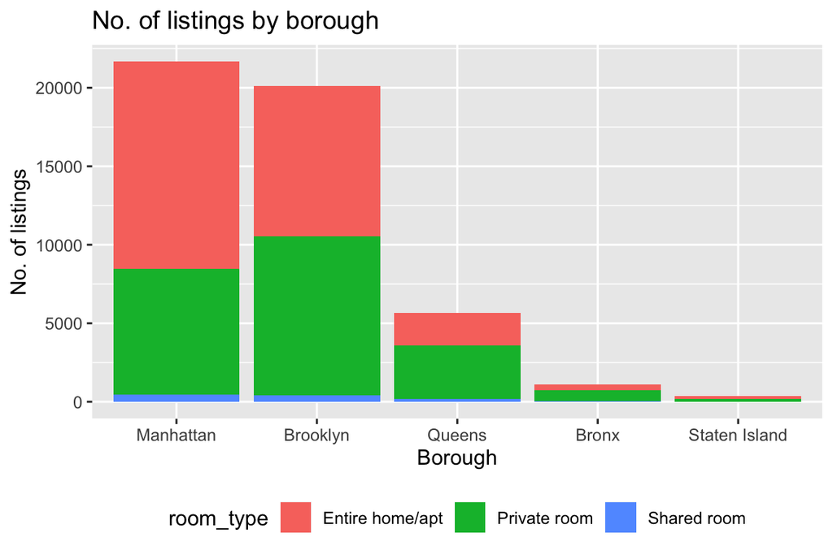

```r
ggplot(df, aes(x = fct_infreq(neighbourhood_group), fill = room_type)) +
    geom_bar() +
    labs(title = "No. of listings by borough",
         x = "Borough", y = "No. of listings") +
    theme(legend.position = "bottom")
```

Below is a plot of the top 10 neighborhoods by number of listings. All of them are either from Brooklyn or Manhattan.

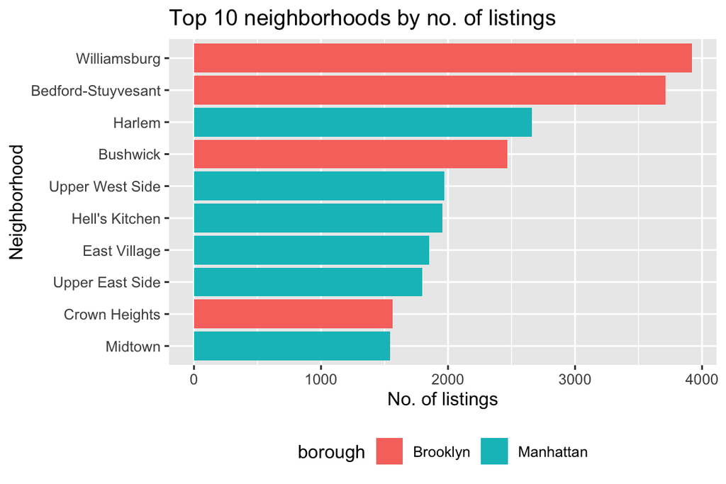

```r
df %>%
    group_by(neighbourhood) %>%
    summarize(num_listings = n(),
              borough = unique(neighbourhood_group)) %>%
    top_n(n = 10, wt = num_listings) %>%
    ggplot(aes(x = fct_reorder(neighbourhood, num_listings),
               y = num_listings, fill = borough)) +
    geom_col() +
    coord_flip() +
    theme(legend.position = "bottom") +
    labs(title = "Top 10 neighborhoods by no. of listings",
         x = "Neighborhood", y = "No. of listings")
```

## Price by room type

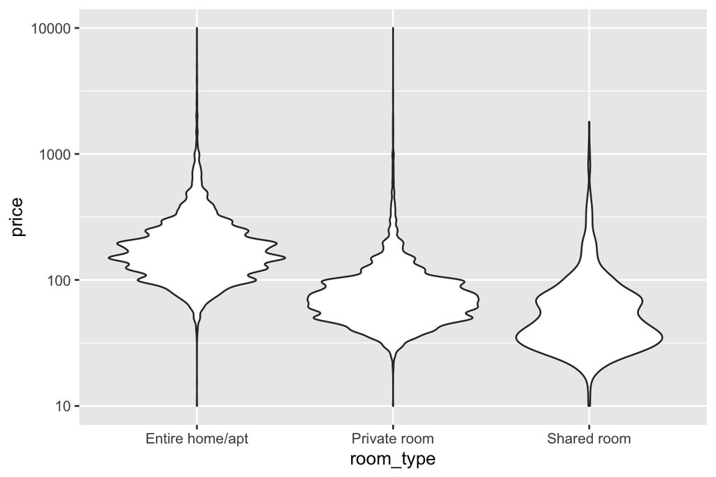

```r
ggplot(df, aes(x = room_type, y = price)) +
    geom_violin() +
    scale_y_log10()
```

In making this plot, we noticed that 11 listings had price as zero. We are not sure why this is the case, but since it is such a small fraction of listings, we will ignore it for this analysis.

```r
df %>% filter(price == 0) %>%
    select(name, host_id, host_name, neighbourhood_group, room_type, minimum_nights)
```

```
## # A tibble: 11 x 6
##    name        host_id  host_name neighbourhood_g… room_type minimum_nights
##    <chr>       <chr>    <chr>     <chr>            <chr>              <dbl>
##  1 Huge Brook… 8993084  Kimberly  Brooklyn         Private …              4
##  2 ★Hostel St… 1316975… Anisha    Bronx            Private …              2
##  3 MARTIAL LO… 15787004 Martial … Brooklyn         Private …              2
##  4 Sunny, Qui… 1641537  Lauren    Brooklyn         Private …              2
##  5 Modern apa… 10132166 Aymeric   Brooklyn         Entire h…              5
##  6 Spacious c… 86327101 Adeyemi   Brooklyn         Private …              1
##  7 Contempora… 86327101 Adeyemi   Brooklyn         Private …              1
##  8 Cozy yet s… 86327101 Adeyemi   Brooklyn         Private …              1
##  9 the best y… 13709292 Qiuchi    Manhattan        Entire h…              3
## 10 Coliving i… 1019705… Sergii    Brooklyn         Shared r…             30
## 11 Best Coliv… 1019705… Sergii    Brooklyn         Shared r…             30
```

## Relationship between number of listings and median price by neighborhood

Does the number of listings in a neighborhood affect the prices of those listings? For each neighborhood, we look at the number of listings as well as its median price. In the plot below, each neighborhood is presented by one point, and its color represents the borough it belongs to.

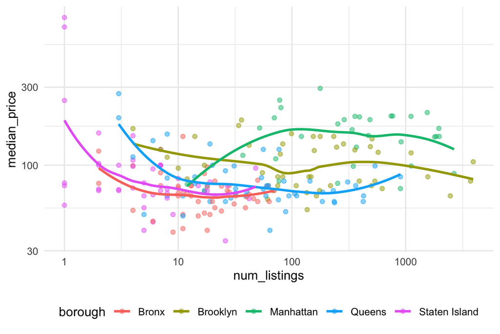

```r
# compute summary statistics for each neighborhood
nhd_df <- df %>%
    group_by(neighbourhood) %>%
    summarize(num_listings = n(),
              median_price = median(price),
              long = median(longitude),
              lat = median(latitude),
              borough = unique(neighbourhood_group))

nhd_df %>%
    ggplot(aes(x = num_listings, y = median_price, col = borough)) +
    geom_point(alpha = 0.5) + geom_smooth(se = FALSE) +
    scale_x_log10() + scale_y_log10() +
    theme_minimal() +
    theme(legend.position = "bottom")
```

Within each borough, it looks like the number of listings in a neighborhood does not have much of an impact on the median price of the listing.

## Map of the top 50 most expensive listings

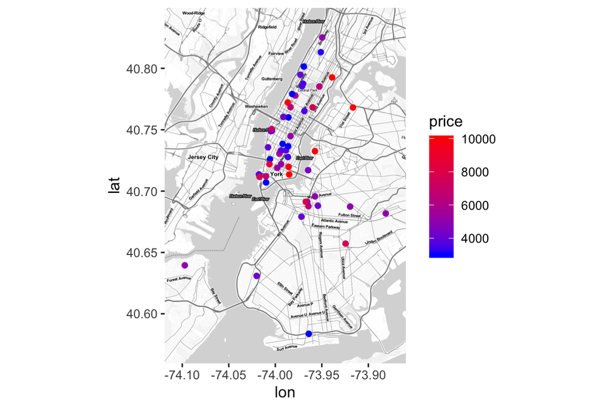

```r
library(ggmap)

# get top 50 listings by price
top_df <- df %>% top_n(n = 50, wt = price)

# get background map
top_height <- max(top_df$latitude) - min(top_df$latitude)
top_width <- max(top_df$longitude) - min(top_df$longitude)
top_borders <- c(bottom  = min(top_df$latitude)  - 0.1 * top_height,
                 top     = max(top_df$latitude)  + 0.1 * top_height,
                 left    = min(top_df$longitude) - 0.1 * top_width,
                 right   = max(top_df$longitude) + 0.1 * top_width)

top_map <- get_stamenmap(top_borders, zoom = 12, maptype = "toner-lite")

# map of top 50 most expensive
ggmap(top_map) +
    geom_point(data = top_df, mapping = aes(x = longitude, y = latitude,
                                        col = price)) +
    scale_color_gradient(low = "blue", high = "red")
```

Most of them are located in Manhattan.

## Median price by neighborhood

In the map below, each dot is one neighborhood. The size of the dot depends on the number of listings and the color of the dot depends on the median price in that neighborhood.

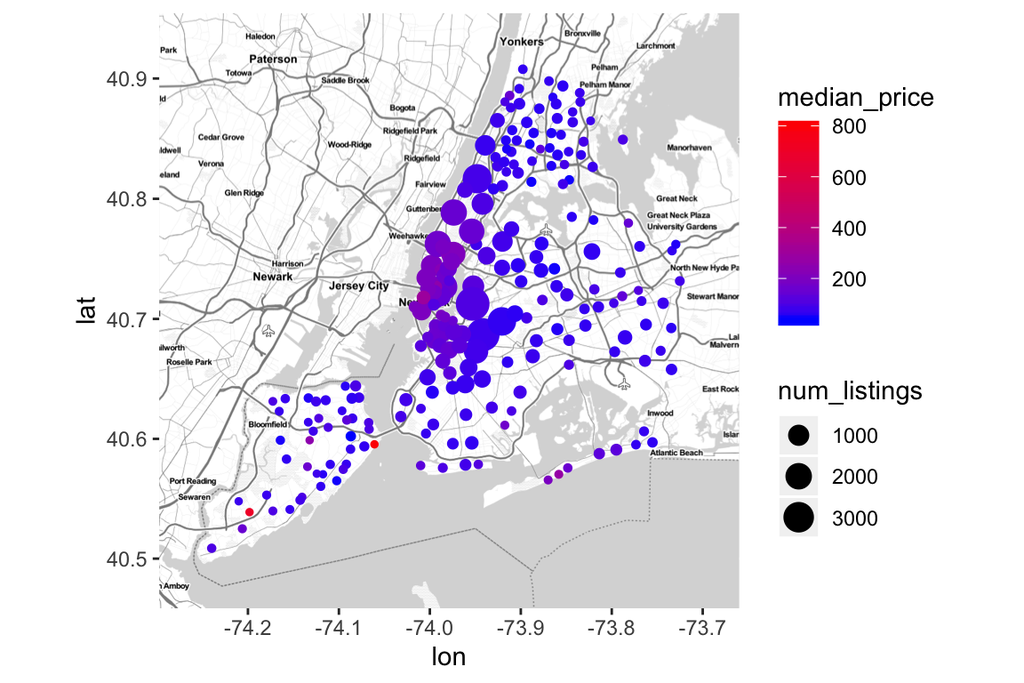

```r
# map of all listings: one point per neighborhood
height <- max(df$latitude) - min(df$latitude)
width <- max(df$longitude) - min(df$longitude)
borders <- c(bottom  = min(df$latitude)  - 0.1 * height,
             top     = max(df$latitude)  + 0.1 * height,
             left    = min(df$longitude) - 0.1 * width,
             right   = max(df$longitude) + 0.1 * width)

map <- get_stamenmap(borders, zoom = 11, maptype = "toner-lite")
ggmap(map) +
    geom_point(data = nhd_df, mapping = aes(x = long, y = lat,
                                            col = median_price, size = num_listings)) +
    scale_color_gradient(low = "blue", high = "red")
```

The median price for most neighborhoods is quite low; it looks somewhat elevated in Manhattan. Also, there are one or two neighborhoods with very high median prices in Staten Island: this is worth investigating further.

## Conclusion

There is much in this dataset that we have not explored yet. At first glance, it appears that room type and neighborhood have an effect on the listing price, but not the number of listings in the neighborhood.